# APAN5205 Whole Foods Analysis

Group 14: Apoorva Grover, Jingwen Mu, Kai Wen, Khushi Mandavia

2024-04-28

# Background

In 2017, Amazon made a significant move in the retail sector by acquiring Whole Foods Market for $13.7 Billion (Tarasov, K. August 2022). This acquisition underscores a strategic focus not only on product expansion but also on gaining valuable consumer insights. Whole Foods provides Amazon with a rich database of customer purchasing behaviors, a key asset in the increasingly data-driven landscape of retail marketing.

However, Whole Foods Market has had to grapple with market saturation, which has tempered its sales growth trajectory. The brand strategically pivots to unveil a new, nimble store concept: **the Whole Foods Market Daily Shop**. This would range between 7,000 to 14,000 square feet. The quick-shop store will be about a quarter to half the footprint of an average 40,000 square-foot Whole Foods Market store, paving the way for expansion in dense, metropolitan areas. Set against the backdrop of an evolving retail landscape, this initiative marks a response to the call for greater convenience and speed in the urban shopper’s experience. With plans to roll out this year, the first of this store in Upper East Side, Manhattan, Whole Foods is adapting to condensed, daily shopping habits, offering a curated assortment of fresh and favorite products designed for the pace of city life. This move represents a bold adaptation of store layout and product selection, aiming to reinvigorate sales growth by aligning with the contemporary rhythms of the modern consumer. (Whole Foods Market Newsroom, March 2024)

For this project, our primary objective is to conduct a thorough market basket analysis of grocery buying habits at Whole Foods locations in New York City. By understanding the relationships and patterns in which products are frequently purchased together, we aim to recommend a store layout to the Whole Foods Daily Shop that optimizes shopping efficiency, enhances customer satisfaction, and increases sales. This would also offer broader strategic benefits for Amazon. By implementing the recommended store changes, Amazon can leverage these insights to enhance the overall effectiveness of its retail strategy across multiple platforms. An optimized store layout at Whole Foods can serve as a pilot for integrating more sophisticated data-driven retail techniques that could be applied across Amazon’s global marketplace.

This analysis will allow us to identify key product pairings and groupings that can inform a more intuitive store design. By rearranging the store to align with natural shopping patterns, Whole Foods can reduce customer journey times, improve the visibility of high-margin products, and potentially encourage larger purchases. Furthermore, an optimized layout can help in managing store traffic better, which is crucial in the bustling urban environment of New York City. We also seek to demonstrate how data-driven strategies can be applied in real-world retail settings to meet consumer needs and business goals effectively.

# Literature Review

In the field of retail optimization, a store’s layout is a critical component influencing consumer behavior. Underhill’s seminal work (2009) demonstrates how creative product placement and shop design may influence consumers’ in-store journeys, eventually impacting their purchasing decisions. Hui et al. (2013) found that streamlined layouts that allow for easier product identification result in greater consumer satisfaction and sales. These ideas are especially relevant to Whole Foods Market, particularly with the introduction of the smaller, more focused Whole Foods Market Daily Shop. This new style is oriented towards urban consumers that prioritize convenience and speed, emphasizing the need for layouts that enable rapid shopping excursions and boost the display of products matched to a city lifestyle.

Efficiency is a key component of customer satisfaction, particularly in urban retail context. Thompson and Arsel (2004) argue that the constricted and hurried lifestyle of city people makes shopping efficiency a critical factor of retail success. Christina Minardi, Executive Vice President of Growth & Development at Whole Foods Market & Amazon, supports this by highlighting the Daily Shop format’s strategic intention: to “tailor every square foot to the unique, fast-paced needs of urban lifestyles,” ensuring that grocery trips are both efficient and enjoyable for urban shoppers. This shift in store size and focus reflects a larger strategy to improve customer connections and advance Whole Foods’ mission to nourish people and our planet.

# Research Questions

**Question 1** - How can we leverage Amazon’s historical purchase data and market basket analysis to design an optimized store layout for the new Upper East Side Whole Foods Market Daily Shop that improves customer flow and maximizes shopping efficiency?

**Question 2** - Using the apriori algorithm, how can we strategically position high-demand and frequently bought products to enhance profitability and encourage impulsive purchases at the new store location?

Our research for the new Upper East Side Whole Foods Market Daily Shop focuses on improving the shopping experience through an in-depth analysis of historical purchase data. We plan to use market basket analysis to offer an optimized store layout designed to speed up the customer movement and maximize shopping efficiency. This section of the study focuses on discovering the most efficient pathways within the shop and strategically putting essential and popular items so that customers spend less time wandering the aisles.

We use the apriori algorithm to discover the best product placement methods based on consumer purchasing habits. By analyzing which products customers usually buy together, we may place these things in a way that naturally compliments the shopper’s journey, increasing the likelihood of purchase without using pricing strategies. This tailored positioning contributes to a more intuitive shopping environment that stimulates more thorough analysis of the store’s items, potentially improving overall purchase levels.

Therefore, our market basket and Apriori algorithm analysis contribute to the creation of a store setting that is more than simply a place to buy, but also a streamlined, intuitive shopping experience adapted to the Upper East Side community’s daily routines. By focusing on efficient paths and clever product placements based on frequent purchasing habits, the store can avoid bottlenecks and make popular and important items more accessible. This shortens the time customers spend in the store, which is important in the convenience-driven market that the Daily Shop aims to cater to.

# Data Analysis

### Data Overview

Our dataset of Whole Foods Market details 24,896 valid transactions, with 249,995 rows revealing specifics of individual product purchases. It includes 23,321 unique product names and IDs, transaction numbers, and reorder statuses while specifying each item’s location in the store through the aisle and 21 unique department IDs alongside the categories they belong to. The details allow for an analysis of shopping habits and product popularity and help optimize store layouts and inventory management. By analyzing this data, the managers can understand customer preferences and buying patterns, making it an essential tool for market research and strategic retail planning to improve the overall customer experience.

### Technical Steps Overview

We imported the transaction data in R and examined it closely, creating summaries and visualizations to illustrate how transactions were distributed across various departments. To ensure the data cleanliness and usefulness for further analysis, we found and removed any records lacking information, either NAs or filled with ‘missing’. Plus, discovering which products were top sellers and which were frequently reordered provides evidence for the manager with the product selection process. Furthermore, We created charts to display the transactions across different departments and aisles, highlighting the areas with the highest sales volumes.

#### Loading Data and Packages

```r
## Loading necessary packages
library(tidyverse)
library(readr)
library(arules)
```

```r
library(arulesViz)
library(RColorBrewer)
library(gridExtra)
library(readr)


## Import data
# dataset location -> 'https://drive.google.com/file/d/1K99Szt8OLXWoS1FvqJy4zfKU-RMMwmVV/view?usp=sharing'

wf <- read_csv("/Users/kaiwen/Desktop/Columbia/APAN 5205/Project/Whole_Foods_Transaction_Data.csv")
```

#### Data Preparation

```r
## Check NAs
summary(wf) # -->> with 5 NA in department
```

```
##  transaction_id      product_id      reordered      product_name
##  Min.   :     10   Min.   :    1   Min.   :0.0000   Length:250000
##  1st Qu.:1003917   1st Qu.:13512   1st Qu.:0.0000   Class :character
##  Median :1010511   Median :25256   Median :1.0000   Mode  :character
##  Mean   : 919816   Mean   :25573   Mean   :0.5878
##  3rd Qu.:1017217   3rd Qu.:38015   3rd Qu.:1.0000
##  Max.   :1023856   Max.   :49683   Max.   :1.0000
##
##     aisle_id      department_id    department           aisle
##  Min.   :  1.00   Min.   : 1.00   Length:250000      Length:250000
##  1st Qu.: 31.00   1st Qu.: 4.00   Class :character   Class :character
##  Median : 83.00   Median : 9.00   Mode  :character   Mode  :character
##  Mean   : 71.29   Mean   : 9.92
##  3rd Qu.:107.00   3rd Qu.:16.00
##  Max.   :134.00   Max.   :21.00
##                   NA's   :5
```

```r
## check how many 'missing' in department
sum(wf$department == "missing") # -->> found 541 rows contain 'missing' in the department column
```

```
## [1] 541
```

```r
## delete rows contain missing
wf_no_missing <- wf %>%
  filter(department != "missing", aisle != "missing")
```

Since the ‘missing’ value only occurs in the department column, we decided to use two versions of the dataset: `wf` for analyzing the relationships between products and `wf_no_missing` that filtered out the ‘missing’ values in department for department analysis.

```r
## remove NAs
wf<-drop_na(wf) # -->> product analysis
wf_no_missing<-drop_na(wf_no_missing) # -->> department analysis
```

#### Association Rules: Department

**Preparation for department association rules analysis:**

1. Group the dataset by each unique transaction ID.
2. Simplify the data and focus on the entire departments within a transaction.
3. Convert to transaction format

```r
## group by id and summarize
department_transations<- wf_no_missing%>%
  group_by(transaction_id)%>%
  summarise(department= list(unique(department)))%>%
  ungroup()

## transform to transaction format
department_transations<- as(department_transations$department,"transactions")
```

**Apriori Function**

```r
rules_department1 <- apriori(department_transations,parameter = list(supp=0.05,conf=0.8))
```

```
## Apriori
##
## Parameter specification:
##  confidence minval smax arem  aval originalSupport maxtime support minlen
##         0.8    0.1    1 none FALSE            TRUE       5    0.05      1
##  maxlen target  ext
##      10  rules TRUE
##
## Algorithmic control:
##  filter tree heap memopt load sort verbose
##     0.1 TRUE TRUE  FALSE TRUE    2    TRUE
##
## Absolute minimum support count: 1244
##
## set item appearances ...[0 item(s)] done [0.00s].
## set transactions ...[20 item(s), 24892 transaction(s)] done [0.00s].
## sorting and recoding items ... [16 item(s)] done [0.00s].
## creating transaction tree ... done [0.00s].
## checking subsets of size 1 2 3 4 5 done [0.00s].
## writing ... [281 rule(s)] done [0.00s].
## creating S4 object  ... done [0.00s].
```

```r
summary(rules_department1)
```

```
## set of 281 rules
##
## rule length distribution (lhs + rhs):sizes
##   2   3   4   5
##  15 100 127  39
##
##    Min. 1st Qu.  Median    Mean 3rd Qu.    Max.
##   2.000   3.000   4.000   3.676   4.000   5.000
##
## summary of quality measures:
##     support          confidence        coverage            lift
##  Min.   :0.05010   Min.   :0.8008   Min.   :0.05464   Min.   :1.085
##  1st Qu.:0.05885   1st Qu.:0.8585   1st Qu.:0.06584   1st Qu.:1.191
##  Median :0.07448   Median :0.8805   Median :0.08549   Median :1.228
##  Mean   :0.09147   Mean   :0.8764   Mean   :0.10578   Mean   :1.237
##  3rd Qu.:0.10152   3rd Qu.:0.8975   3rd Qu.:0.11723   3rd Qu.:1.297
##  Max.   :0.54552   Max.   :0.9331   Max.   :0.67516   Max.   :1.370
##      count
##  Min.   : 1247
##  1st Qu.: 1465
##  Median : 1854
##  Mean   : 2277
##  3rd Qu.: 2527
##  Max.   :13579
##
## mining info:
##                    data ntransactions support confidence
##  department_transations         24892    0.05        0.8
##                                                                               call
##  apriori(data = department_transations, parameter = list(supp = 0.05, conf = 0.8))
```

```r
two_item_rules = subset(rules_department1, subset = size(lhs(rules_department1)) + size(rhs(rules_department1)) == 2)

sorted_rules_department1 <- sort(two_item_rules, by = "lift", decreasing = TRUE)
inspect(head(sorted_rules_department1,n=5))
```

```
##     lhs                  rhs          support   confidence coverage   lift
## [1] {dry goods pasta} => {dairy eggs} 0.1522578 0.8291402  0.18363330 1.228071
## [2] {breakfast}       => {dairy eggs} 0.1322513 0.8265127  0.16001125 1.224179
## [3] {bakery}          => {dairy eggs} 0.2199904 0.8162170  0.26952435 1.208930
## [4] {deli}            => {dairy eggs} 0.1928732 0.8083853  0.23859071 1.197330
## [5] {international}   => {dairy eggs} 0.0533103 0.8008449  0.06656757 1.186162
##     count
## [1] 3790
## [2] 3292
## [3] 5476
## [4] 4801
## [5] 1327
```

#### Association Rules: Product

**Preparation for product association rules analysis:**

1. Group the dataset by each unique transaction ID.
2. Focus on the products within a transaction.
3. Convert to transaction format

```r
## group by id and summarize
transactions<-wf%>%
  group_by(transaction_id)%>%
  summarise(items = list(product_name))%>%
  ungroup()

## transform to transaction format
transactions <- as(transactions$items, "transactions")
```

**Apriori Function**

```r
rules1 <- apriori(transactions,parameter = list(supp=0.00035,conf=0.5))
```

```
## Apriori
##
## Parameter specification:
##  confidence minval smax arem  aval originalSupport maxtime support minlen
##         0.5    0.1    1 none FALSE            TRUE       5 0.00035      1
##  maxlen target  ext
##      10  rules TRUE
##
## Algorithmic control:
##  filter tree heap memopt load sort verbose
##     0.1 TRUE TRUE  FALSE TRUE    2    TRUE
##
## Absolute minimum support count: 8
##
## set item appearances ...[0 item(s)] done [0.00s].
## set transactions ...[23321 item(s), 24896 transaction(s)] done [0.05s].
## sorting and recoding items ... [4797 item(s)] done [0.00s].
## creating transaction tree ... done [0.00s].
## checking subsets of size 1 2 3 4 5 done [0.07s].
## writing ... [633 rule(s)] done [0.03s].
## creating S4 object  ... done [0.00s].
```

```r
summary(rules1)
```

```
## set of 633 rules
##
## rule length distribution (lhs + rhs):sizes
##   2   3   4
##  32 420 181
##
##    Min. 1st Qu.  Median    Mean 3rd Qu.    Max.
##   2.000   3.000   3.000   3.235   4.000   4.000
##
## summary of quality measures:
##     support            confidence        coverage              lift
##  Min.   :0.0003615   Min.   :0.5000   Min.   :0.0003615   Min.   :   3.401
##  1st Qu.:0.0003615   1st Qu.:0.5263   1st Qu.:0.0006025   1st Qu.:   4.337
##  Median :0.0004017   Median :0.5625   Median :0.0007230   Median :   7.405
##  Mean   :0.0004688   Mean   :0.5934   Mean   :0.0008115   Mean   :  51.124
##  3rd Qu.:0.0004820   3rd Qu.:0.6429   3rd Qu.:0.0008837   3rd Qu.:  63.349
##  Max.   :0.0018477   Max.   :1.0000   Max.   :0.0036150   Max.   :1077.231
##      count
##  Min.   : 9.00
##  1st Qu.: 9.00
##  Median :10.00
##  Mean   :11.67
##  3rd Qu.:12.00
##  Max.   :46.00
##
## mining info:
##          data ntransactions support confidence
##  transactions         24896 0.00035        0.5
##                                                                        call
##  apriori(data = transactions, parameter = list(supp = 0.00035, conf = 0.5))
```

```r
inspect(head(rules1, n = 5))
```

```
##     lhs                                                                    rhs                                                         support confidence     coverage       lift count
## [1] {Almond Snack Crackers}                                             => {Banana}                                               0.0003615039  0.6428571 0.0005623393   4.372834     9
## [2] {Dairy Free Coconut Milk Yogurt Alternative}                        => {Dairy Free Coconut Milk Blueberry Yogurt Alternative} 0.0004016710  0.5882353 0.0006828406 665.668449    10
## [3] {Blueberry Crisp Energy Bar}                                        => {Banana}                                               0.0003615039  0.5625000 0.0006426735   3.826230     9
## [4] {Dairy Free Coconut Milk Raspberry Yogurt Alternative}              => {Dairy Free Coconut Milk Blueberry Yogurt Alternative} 0.0004016710  0.5263158 0.0007631748 595.598086    10
## [5] {Oh My Yog! Organic Wild Quebec Blueberry Cream Top Yogurt & Fruit} => {Oh My Yog! Pacific Coast Strawberry Trilayer Yogurt}  0.0004016710  0.6250000 0.0006426735 676.521739    10
```

# Results Evaluation and Recommendations

#### Transactions Across Departments and Aisles

**Top 10 Departments by Transaction Count**

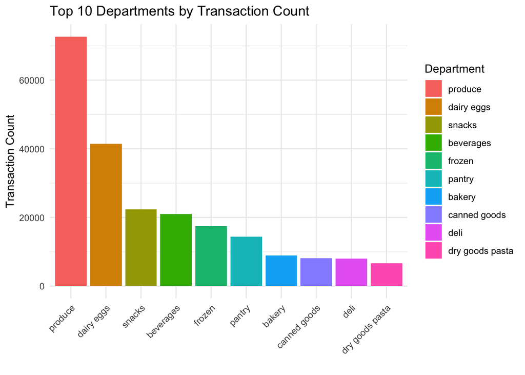

```r
# Group by department, count transactions
portfolio <- wf %>%
  group_by(department) %>%
  summarise(total_count = n(), .groups = 'drop')

# Convert department to a factor and order by total_count
portfolio$department <- factor(portfolio$department, levels = portfolio$department[order(-portfolio$total_count)])

# Select the top 10 departments
top_departments <- portfolio %>%
  top_n(10, total_count)

# Plot
ggplot(top_departments, aes(x = department, y = total_count, fill = department)) +
  geom_col() +
  labs(title = "Top 10 Departments by Transaction Count",
       y = "Transaction Count", x = "") +
  scale_fill_discrete(name = "Department") +
  theme_minimal() +
  theme(axis.text.x = element_text(angle = 45, hjust = 1))
```

**Top 15 Aisles by Transaction Count**

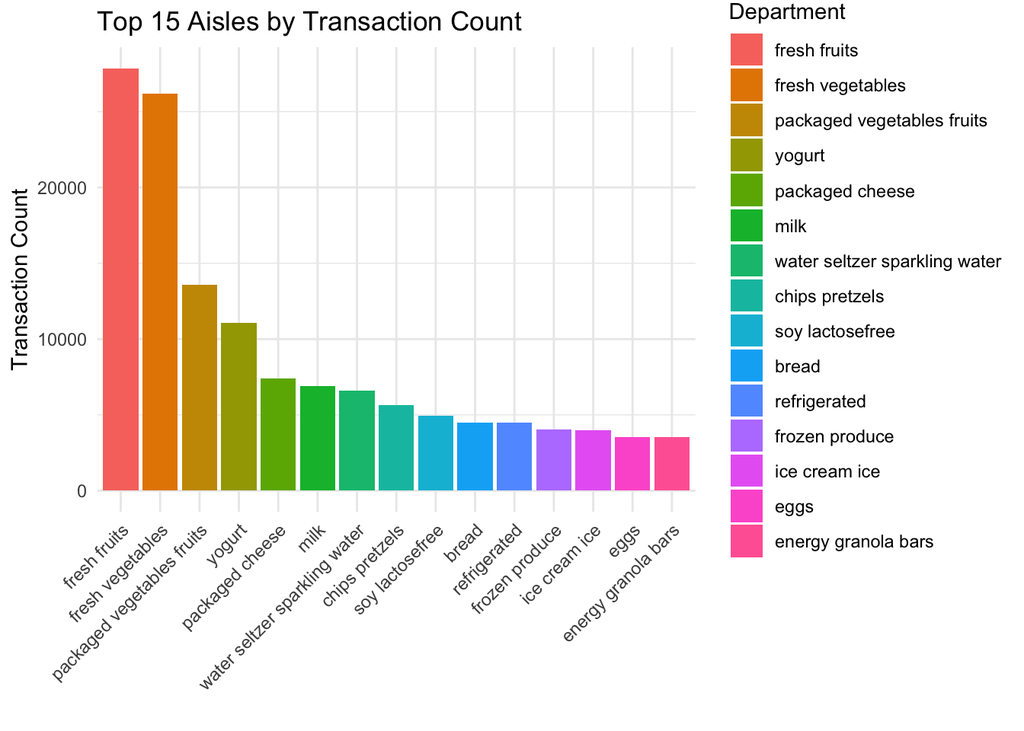

```r
# Group by aisles, count transactions
portfolio <- wf %>%
  group_by(aisle) %>%
  summarise(total_count = n(), .groups = 'drop')

# Convert aisles to a factor and order by total_count
portfolio$aisle <- factor(portfolio$aisle, levels = portfolio$aisle[order(-portfolio$total_count)])

# Select the top 15 aisles
top_aisles <- portfolio %>%
  top_n(15, total_count)

# Plot
ggplot(top_aisles, aes(x = aisle, y = total_count, fill = aisle)) +
  geom_col() +
  labs(title = "Top 15 Aisles by Transaction Count",
       y = "Transaction Count", x = "") +
  scale_fill_discrete(name = "Department") +
  theme_minimal() +
  theme(axis.text.x = element_text(angle = 45, hjust = 1))
```

**Analysis**:The high volume of transactions in the ‘produce’ department highlights its central role in daily shopping, primarily driven by the consistent purchase of fresh fruits and vegetables. Following closely are ‘dairy eggs’ which reflect their essential role in everyday diets. The ‘snacks’ and ‘beverages’ departments also report substantial activity, indicating a regular demand for items that are enjoyed throughout the day, from morning coffee to afternoon treats. This suggests a consistent consumer preference for not only fresh, ready-to-eat foods but also convenient snack and drink options.

Lower in the hierarchy, the ‘frozen,’ ‘pantry,’ and ‘bakery’ items show slightly lesser transaction volumes, indicating routine but less frequent purchases compared to the top categories. Essential items bought less often are canned goods, deli, and dry goods such as pasta, which are important but see the fewest transactions. This distribution of shopping activity highlights varied consumer habits and preferences across different food departments.

**Recommendation for Whole Foods Market Daily Shop**: Based on our analysis, we recommend that the product assortment for the new Whole Foods Market Daily Shop should prioritize departments with high transaction volumes, such as ‘produce’ and ‘dairy eggs’. These areas have frequent customer activity and should be made easily accessible. They form the foundation of the Daily Shop’s offerings. The ‘snacks’ and ‘beverages’ departments are also important and attract considerable customer traffic, so they should be conveniently placed to facilitate quick and easy shopping. Departments like ‘frozen’, ‘pantry’, and ‘bakery’, despite their lower transaction volumes, still play a crucial role. For these categories, we suggest primarily stocking bestsellers or frequently purchased items, supplementing them with selections from higher-traffic areas. This approach allows us to cater to customers looking for a swift shopping experience without overwhelming them with excessive choices. Maintaining a focus on convenience and efficiency, which are fundamental to the Daily Shop concept.

#### Top products by count

**Top 30 Products Bought**

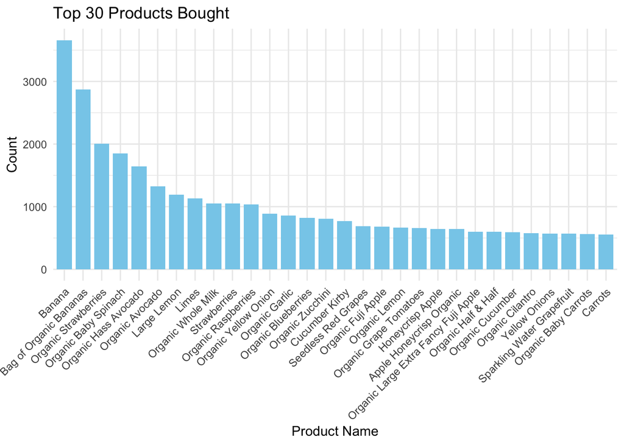

```r
wf1 <- wf %>%
  group_by(product_name) %>%
  summarise(count = n()) %>%
  arrange(desc(count))

ggplot(head(wf1, 30),
       aes(x = reorder(product_name, -count),y = count)) +
  geom_bar(stat = "identity", fill = "skyblue", width = 0.8) +
  labs(x = "Product Name", y = "Count", title = "Top 30 Products Bought") +
  theme_minimal() +
  theme(axis.text.x = element_text(angle = 45, hjust = 1))
```

**Broad Overview**: The top 30 products chartered offer a panoramic view of shopping trends at Whole Foods, presenting which items customers pick up most. The product list highlights the value of fresh produce, with organic options being particularly popular. This shows that customers are health-conscious and prefer organic certification.

**Analysis**: Conventional and organic bananas are the most popular among customers, suggesting their importance in their diet. Berries and avocados also rank high, which could be attributed to their adaptability and popularity in recent health trends. Dairy products such as whole milk and half-and-half appear, as do staple vegetables such as lemons, limes, onions, and garlic, all of which are essential cooking elements.

**Recommendation for Whole Foods Market Daily Shop**: Given the popularity of fresh and organic produce, the Daily Shop should dedicate more shop space to these items, ensuring that they are the first products visitors see when they arrive. Highlighting organic options can appeal to health-conscious shoppers seeking quality and freshness.

Bananas and berries can be strategically placed to capture the eye, and they can be paired with other cross-promotional health-focused products such as organic nut butters or yogurt. Essential vegetables and fruits, such as onions, garlic, and apples, should be easily available, establishing the foundation of a middle-aisle loop that shoppers can quickly explore.

In the beverage department, items such as sparkling water can be put near checkout sections as a grab-and-go option. Finally, to meet the different needs of urban shoppers, the store might provide pre-packaged bundles of these top-selling produce items for increased convenience, appealing to those on the go who want to shop fast and efficiently.

This tailored approach in the Daily Shop is anticipated to improve the shopping experience by making it faster and more intuitive, resulting in improved customer satisfaction and increased sales volumes, which aligns with Whole Foods’ goal of providing high-quality, easy shopping solutions.

#### Products Pairs

**Product Frequent Bought Together**

```r
sorted_rules1 <- sort(rules1, by='lift', decreasing = T)
inspect(head(sorted_rules1, n = 10))
```

```
##      lhs                                                                     rhs                                                                       support confidence     coverage      lift count
## [1]  {Stage 3 Hearty Meals - Chick Chick Organic Baby Food}               => {Gobble Gobble Turkey Pouch Stage 3}                                 0.0003615039  0.6923077 0.0005221722 1077.2308     9
## [2]  {Gobble Gobble Turkey Pouch Stage 3}                                 => {Stage 3 Hearty Meals - Chick Chick Organic Baby Food}               0.0003615039  0.5625000 0.0006426735 1077.2308     9
## [3]  {Mighty 4 Kale, Strawberry, Amaranth & Greek Yogurt Tots Snack}      => {Mighty 4 Purple Carrot Blackberry Quinoa & Greek Yogurt Tots Snack} 0.0003615039  0.5625000 0.0006426735  700.2000     9
## [4]  {Organic Fruit Yogurt Smoothie Mixed Berry}                          => {Organic Strawberry Banana Fruit Yogurt Smoothie}                    0.0003615039  0.6000000 0.0006025064  678.9818     9
## [5]  {Oh My Yog! Organic Wild Quebec Blueberry Cream Top Yogurt & Fruit}  => {Oh My Yog! Pacific Coast Strawberry Trilayer Yogurt}                0.0004016710  0.6250000 0.0006426735  676.5217    10
## [6]  {Mighty 4 Kale, Strawberry, Amaranth & Greek Yogurt Tots Snack}      => {Mighty 4 Sweet Potato, Blueberry, Millet & Greek Yogurt Tots Snack} 0.0004016710  0.6250000 0.0006426735  676.5217    10
## [7]  {Dairy Free Coconut Milk Yogurt Alternative}                         => {Dairy Free Coconut Milk Blueberry Yogurt Alternative}               0.0004016710  0.5882353 0.0006828406  665.6684    10
## [8]  {Dairy Free Coconut Milk Raspberry Yogurt Alternative}               => {Dairy Free Coconut Milk Blueberry Yogurt Alternative}               0.0004016710  0.5263158 0.0007631748  595.5981    10
## [9]  {Oh My Yog! Madagascar Vanilla Trilayer Yogyurt}                     => {Oh My Yog! Pacific Coast Strawberry Trilayer Yogurt}                0.0004418380  0.5000000 0.0008836761  541.2174    11
## [10] {Mighty 4 Purple Carrot Blackberry Quinoa & Greek Yogurt Tots Snack} => {Mighty 4 Sweet Potato, Blueberry, Millet & Greek Yogurt Tots Snack} 0.0004016710  0.5000000 0.0008033419  541.2174    10
```

**Broad Overview**:The market basket analysis for Whole Foods Market Daily Shop uses historical purchase data to determine how products are frequently purchased together.This technique recognises pairs and groups of items that are frequently purchased together, providing insight into the combinations that shoppers prefer.

**Analysis**:The strongest product correlation observed is between ‘Stage 3 Hearty Meals - Chick Chick Organic Baby Food’ and ‘Gobble Gobble Turkey Pouch Stage 3’, with a lift of over 1000 and high confidence, showing parents frequently purchase both items together. Other major pairs include the Mighty 4 and Oh My Yog! product, indicating a consumer appetite for varied, health-conscious snack options. These connections, supported by strong lift and confidence ratings, represent a small but essential customer sector focused on nutritious and convenient food options.

**Recommendation for Whole Foods Market Daily Shop**:In response to these findings, Whole Foods Daily Shop should consider grouping these highly associated products to provide a more seamless shopping experience. A separate section for baby food pairs that reflects their complementing purchasing habits would be great. For the yogurt and snack combinations, establishing a ‘better-for-you’ snack zone may stimulate multiple purchases. The emphasis on these strategic groupings is expected to not only improve the shopping experience, but also raise overall transaction value, attracting health-conscious shoppers and busy parents searching for quick, nutritious options. This thorough curation is ideally aligned with Whole Foods’ Daily Shop aim of providing quick and thoughtful product selections customized to the lifestyles of their urban customers.

# Project Limitations/What more is needed

We faced certain limitations in crafting our market basket analysis for Whole Foods. We lacked access to detailed customer traffic flow data, which is crucial for optimizing store layout but is often kept confidential by retailers. Similarly, in-depth product attributes like pricing, brand information, and organic labeling, which could enhance our understanding of purchase drivers, remained beyond our reach as they are typically guarded for competitive advantage. Information on the frequency and timing of repeat purchases was also unavailable, hindering our ability to assess customer loyalty patterns. Furthermore, customer-specific data that would allow for rich behavioral segmentation is restricted due to privacy concerns. We were also unable to account for the influence of sales promotions and external economic factors, as such data is not publicly disclosed. Our findings and recommendations are thus made with the understanding that these constraints are par for the course in retail analytics research, and future work would benefit greatly from direct access to these data facets through a partnership with Whole Foods.

# Conclusion

As Whole Foods Market faces market saturation challenges, the introduction of the Whole Foods Market Daily Shop stands out as a strategic innovation aimed at revitalizing the brand’s urban presence and increasing revenue. Our market basket analysis serves as an important component of this approach, providing a data-driven suggestion for the shop layout of the very first Daily Shop on the Upper East Side. Our recommendations are targeted to optimize consumer flow and shopping efficiency through rigorous analysis of purchasing trends and identification of important product combinations. This strategy is not only an adaptation to new buying habits, but a purposeful endeavor to streamline and improve the customer experience. The alignment of high-frequency items, along with thoughtful product placement, has the potential to transform the Daily Shop into a symbol of convenience and efficiency. As Whole Foods prepares to launch this new concept, our analysis provides a forward-thinking blueprint that combines customer insight and retail knowledge, with the goal of propelling Whole Foods to the forefront of urban grocery shopping.

# References

- Whole Foods Market Newsroom. (2024, March 4). Whole foods market to open smaller format stores as part of ongoing expansion. Whole Foods Market. https://media.wholefoodsmarket.com/whole-foods-market-to-open-smaller-format-stores-as-part-of-ongoing-expansion/
- Whole foods market. Exchange Right. (n.d.). https://www.exchangeright.com/tenant-profiles/whole-foods-market/ Tarasov, K. (2022, August 25). Amazon bought Whole Foods five years ago for $13.7 billion. here’s what’s changed at the high-end grocer. CNBC. https://www.cnbc.com/2022/08/25/how-whole-foods-has-changed-in-the-five-years-since-amazon-took-over.html
- Mourdoukoutas, P. (2024, March 7). Two problems with Whole Foods’ business model. Forbes. https://www.forbes.com/sites/panosmourdoukoutas/2017/02/12/two-problems-with-whole-foods-business-model/?sh=51382acf4839
- Underhill, P. (2009). Why We Buy: The Science of Shopping—Updated and Revised for the Internet, the Global Consumer, and Beyond. Simon and Schuster. https://www.academia.edu/6789902/Why_We_Buy_The_science_of_shopping_Paco_Underhill_Qwerty80_
- Hui, S. K., Bradlow, E. T., & Fader, P. S. (2013). The Traveling Salesman Goes Shopping: The Systematic Deviations of Grocery Paths from TSP Optimality. Marketing Science, 32(5), 717-739 https://core.ac.uk/download/pdf/132271045.pdf
- Thompson, C.J., & Arsel, Z. (2004). The Starbucks Brandscape and the Discursive Mapping of Local Coffee Shop Cultures. Journal of Consumer Research. [https://www.researchgate.net/publication/247560576_The_Starbucks_Brandscape_and_Consumers’_Anticorporate_Experiences_of_Glocalization](https://www.researchgate.net/publication/247560576_The_Starbucks_Brandscape_and_Consumers'_Anticorporate_Experiences_of_Glocalization)
- Dataset location: https://drive.google.com/file/d/1K99Szt8OLXWoS1FvqJy4zfKU-RMMwmVV/view?usp=sharing
- Data Source: https://www.kaggle.com/datasets/jasonyu001/whole-foods-transaction-data